# Why I Would Stick to PowerPoint

[figure not shown]

Anita Lyubenova

2023-02-21

# Positioning of elements

I like my presentations visual

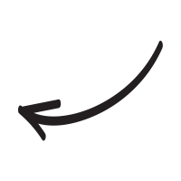

To guide the attention of the audience I use arrows, pop-ups, and text with different formatting

This slide can be made very quickly in PowerPoint (or any other drag-and-drop program). Making it in Rmarkdown involved google-ing a bunch of CSS commands, troubleshooting when some of them did not work, and waiting for the document to knit after every small change in the code. Positioning the elements will be exponentially more time consuming with the number of elements. And sometimes I do have many elements (see next slide).

# Incremental slides

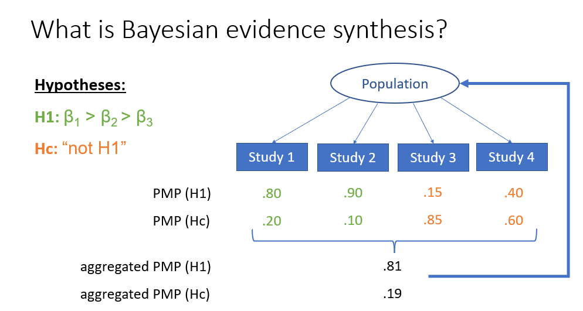

Note: this is a screenshot of a slide from one of my presentations that had many elements (for further reading on Bayesian evidecnce synthesis, see Kuiper et al. (2013) They were showing up/getting colored incrementally while I was presenting - a feature that seems to work only for bullet points in slidy and ioslides presentations.

# Interactivity

One of the advantages is the possibility to implement interactive plots. However, despite being cool, they can be quite confusing for the audience and cause an information overload.

[interactive chart not shown]

# R code

While it is generally useful to show R code, the formatting is not that nice and will cost additional time to fix. (code for the interactive plot above)

```r
 nodes <-  jsonlite::fromJSON("https://raw.githubusercontent.com/datastorm-open/datastorm-open.github.io/master/visNetwork/data/nodes_miserables.json")

 edges <-  jsonlite::fromJSON("https://raw.githubusercontent.com/datastorm-open/datastorm-open.github.io/master/visNetwork/data/edges_miserables.json")

visNetwork(nodes, edges, height = "700px", width = "100%",
            main = "Les miserables",
           footer = paste0("From: ", "https://datastorm-open.github.io/visNetwork/options.html")) %>%
  visOptions(selectedBy = "group",
             highlightNearest = TRUE,
             nodesIdSelection = TRUE) %>%
  visPhysics(stabilization = FALSE)
```

# Tables - Yay!

Creating good-looking tables is indeed easier than with PowerPoint! It spares you the copy-pasting of numbers. Yet again, I don’t find the interactivity too useful.

|  | Sepal.Length | Sepal.Width | Petal.Length | Petal.Width | Species |
| --- | --- | --- | --- | --- | --- |
| 1 | 5.1 | 3.5 | 1.4 | 0.2 | setosa |
| 2 | 4.9 | 3 | 1.4 | 0.2 | setosa |
| 3 | 4.7 | 3.2 | 1.3 | 0.2 | setosa |
| 4 | 4.6 | 3.1 | 1.5 | 0.2 | setosa |
| 5 | 5 | 3.6 | 1.4 | 0.2 | setosa |
| 6 | 5.4 | 3.9 | 1.7 | 0.4 | setosa |

# Equations - Yay!

Being able to write equations in latex is another useful feature of R Markdown presentations. I have often wished they had it in PowerPoint.

$$\begin{align*}
Y \sim X\beta_0 + X\beta_1 + &\epsilon, \\
&\epsilon \sim N(0,\sigma^2)
\end{align*}$$

# Conclusion

Even though I really enjoy working with R, I do not yet consider creating presentations with R Markdown to be worthwhile for my purposes. Designing the slides is more time-consuming, my creativity is hampered by technical hiccups, and the end result is not a better presentation.

# Taking a broader perspective

For this presentation, I considered only the type of presentations I most commonly make - concise presentations that aim to convey a specific message or be persuasive, knowing that the audience will not make use of the slides later on.

I acknowledge that R Markdown may have higher value when the purposes are different. For instance, in teaching materials interactivity would be more advantageous, as the students would study the slides after the lecture.

# References

Kuiper, Rebecca M., Vincent Buskens, Werner Raub, and Herbert Hoijtink. 2013. “Combining Statistical Evidence from Several Studies: A Method Using Bayesian Updating and an Example from Research on Trust Problems in Social and Economic Exchange.” *Sociological Methods & Research* 42 (1): 60–81. https://doi.org/10.1177/0049124112464867.